# The Amazing Leaf

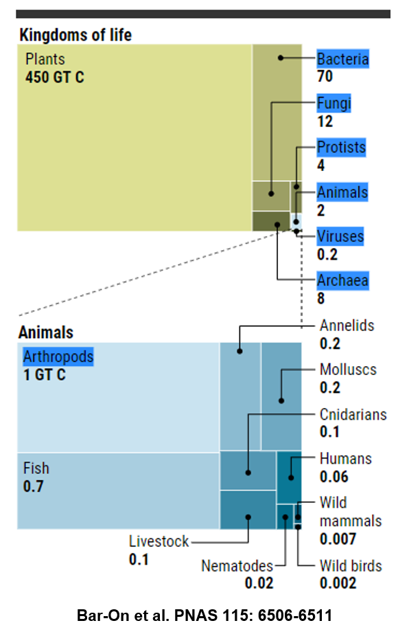

**Where does all this biomass come from?**

## Leaf structure and why it matters

[figure not shown]

## Leaves exchange gases via stomata

**Stomatal opening is a balance between photosynthesis & drying out**

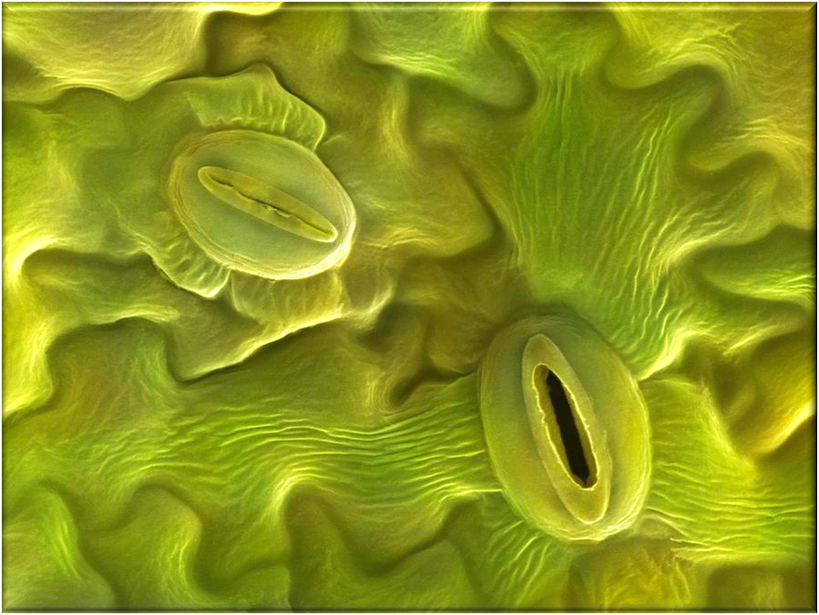

[figure not shown]

## Leaf gas exchange impacts the composition of our atmosphere

[figure not shown]

## Active vs Passive stomatal control

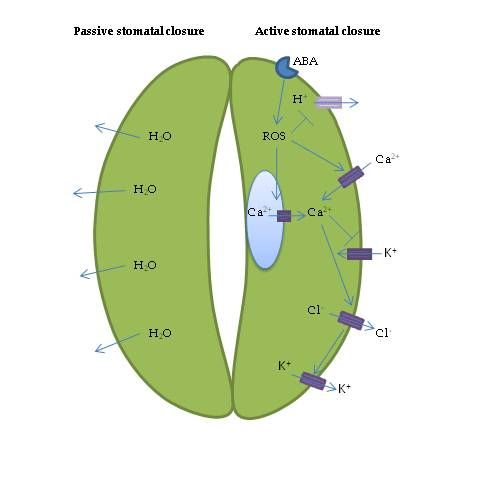

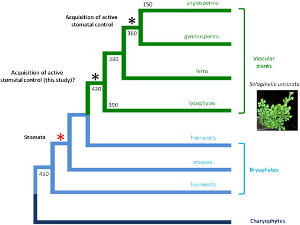

## Vascular tissues in leaves are confined to veins

- *Transpiration* is a by‐product of opening stomatal pores
- **H<sub>2</sub>O transport needs to be sufficient to keep stomata open**
- **Venation represents investment in H<sub>2</sub>O supply**

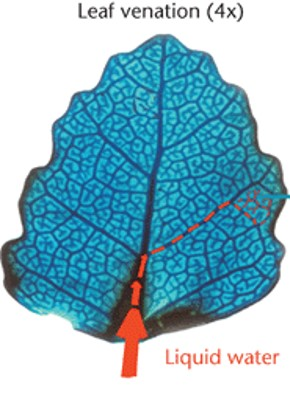

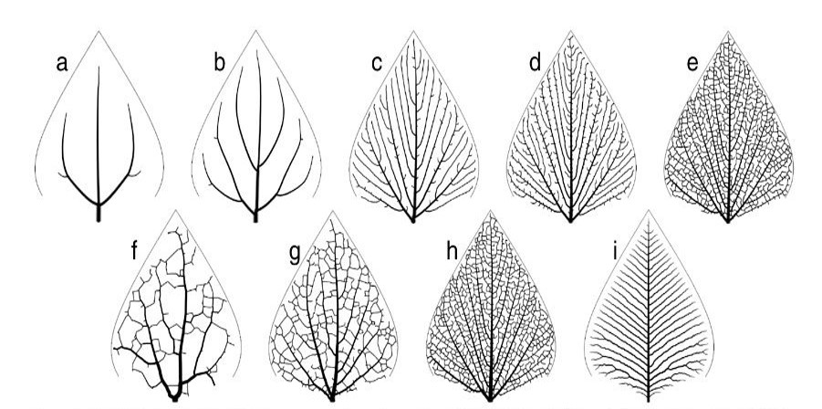

## How leaf veins changed altered plant evolution…

**The density of veins has increased 3-5x in angiosperms vs non-angiosperms**

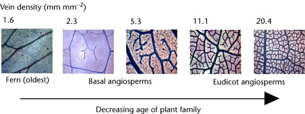

## Plants are autotrophic…what does that really mean?

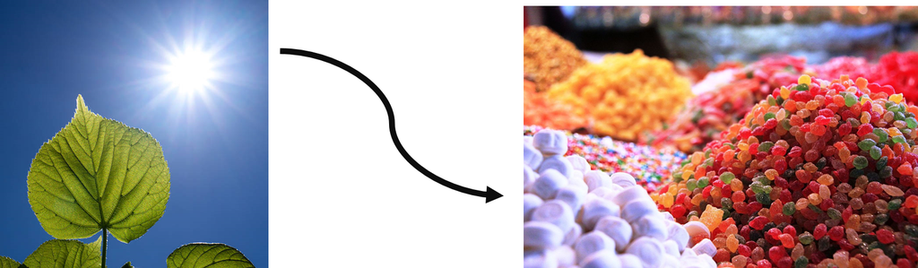

[figure not shown]

## Photosynthesis is the basis for most life on Earth

- **Greek = “building with light”**
- **Autotroph = “self nourishing”**
- **Photoautotroph = “self nourishing with light”**
- **Photosynthesis is an energy pathway**
  - 2 linked reactions inside the chloroplast organelles
  - light reaction + Calvin cycle

[figure not shown]

## Chloroplasts: Where photosynthesis takes place

[figure not shown]

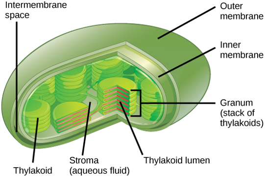

## The nature of light

[figure not shown]

## When light hits chlorophyll a few things can happen

[figure not shown]

[figure not shown]

## When pigments absorb photons an election gets excited

**The antenna complex (pigments bound together) acts like a solar panel, gathering light and passing the energy to the reaction center to power photosynthesis**

[figure not shown]

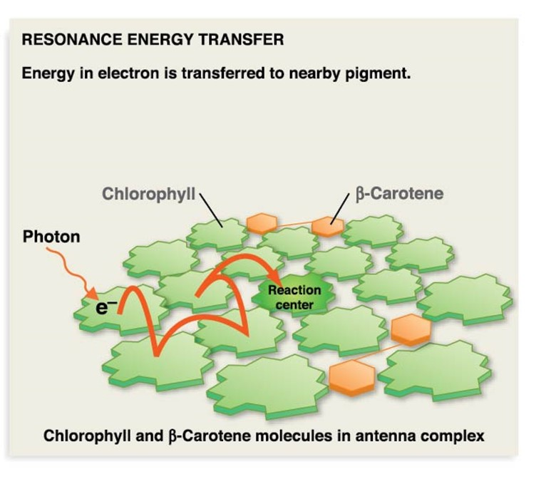

## Photosystems (2) convert light energy to chemical energy

[figure not shown]

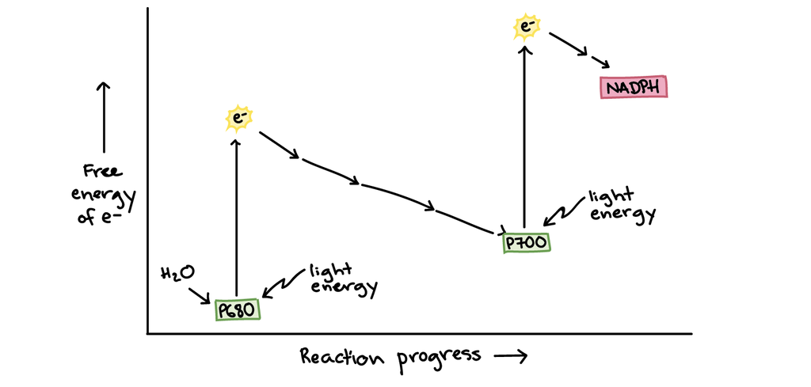

[figure not shown]

## Light reactions: make ATP + NADPH for Calvin cycle

[figure not shown]

## The Calvin Benson cycle makes sugar

[figure not shown]

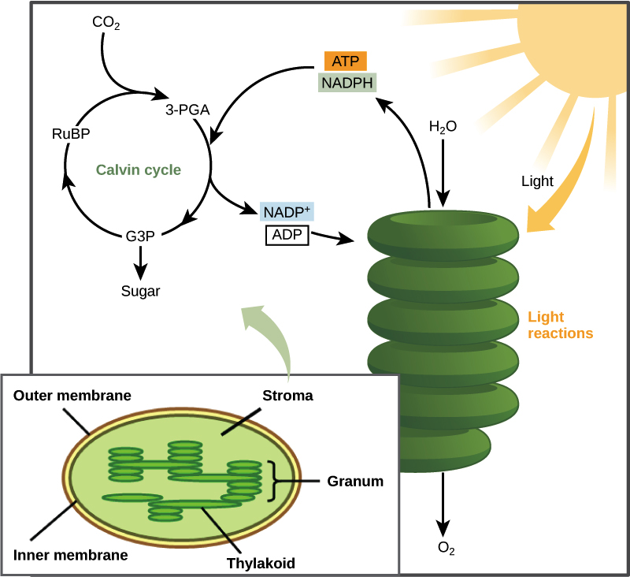

## Calvin cycle is a 3-step process

[figure not shown]

- **1. Fixation: CO<sub>2</sub> reacts with 5C molecule (RUBP)**
  - new 6C split into 2 acids (3C each)
  - catalyzed by Rubisco enzyme
- **2. ATP and NADPH turn 3C acids into sugars**
  - reduction of acids
- **3. Some 3C sugars recycled to make RUBP (5C)**
  - one 3C sugar leaves to make glucose
  - recycling step also needs ATP

## Making sugars requires several cycles

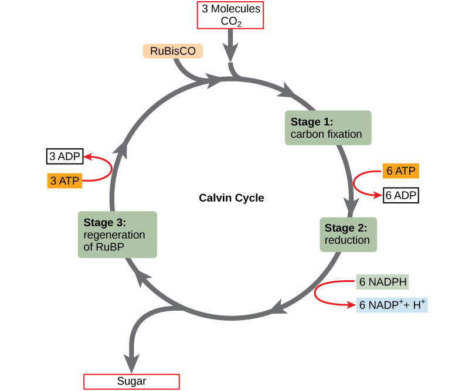

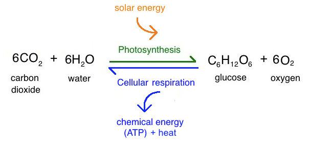

## The brillance of photosynthesis

- **Light energy to synthesize something…**
  - is light limiting?
- **Carbon dioxide & H<sub>2</sub>O are everywhere**
  - easily diffuse into plant
  - contain little chemical energy
  - non-toxic
- **Chemical energy made includes ATP**
  - high energy
  - movable
  - recyclable

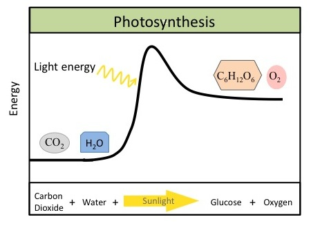

## Calvin Benson won a Nobel prize, his TA won best practical joke

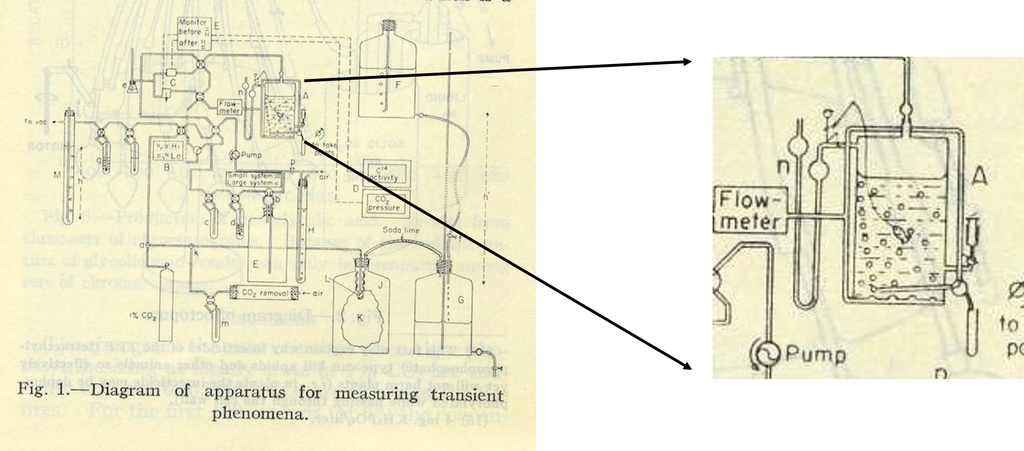